# Movie Success Prediction

After the evolution of Facebook in 2005, people used to rank the movies in the FB by liking the movies.The Facebook rating of movies have increased over years and people are interested in liking the movies that are impressive. This liking system acts as a medium to say that whether a movie is better or good or average or flop.

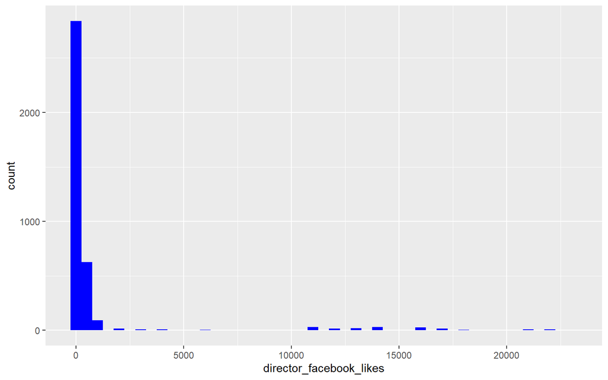

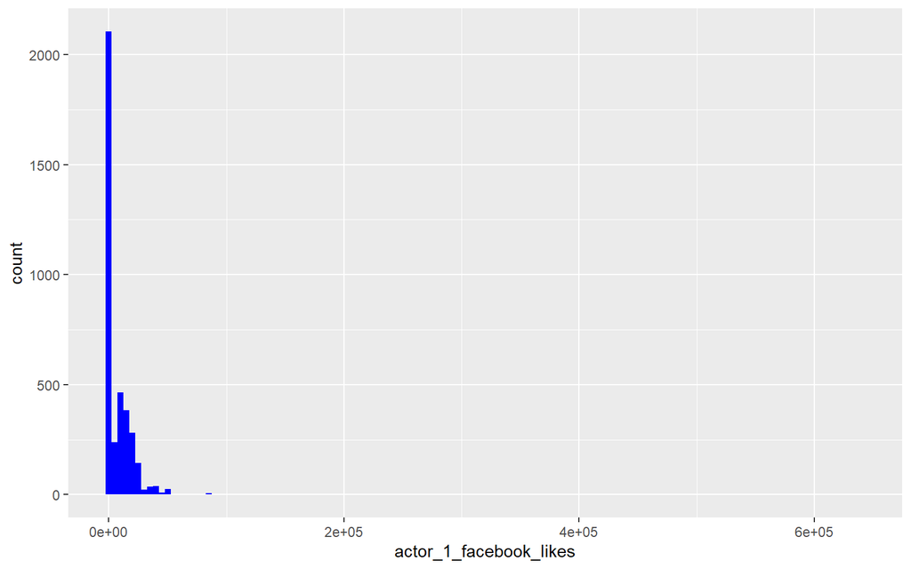

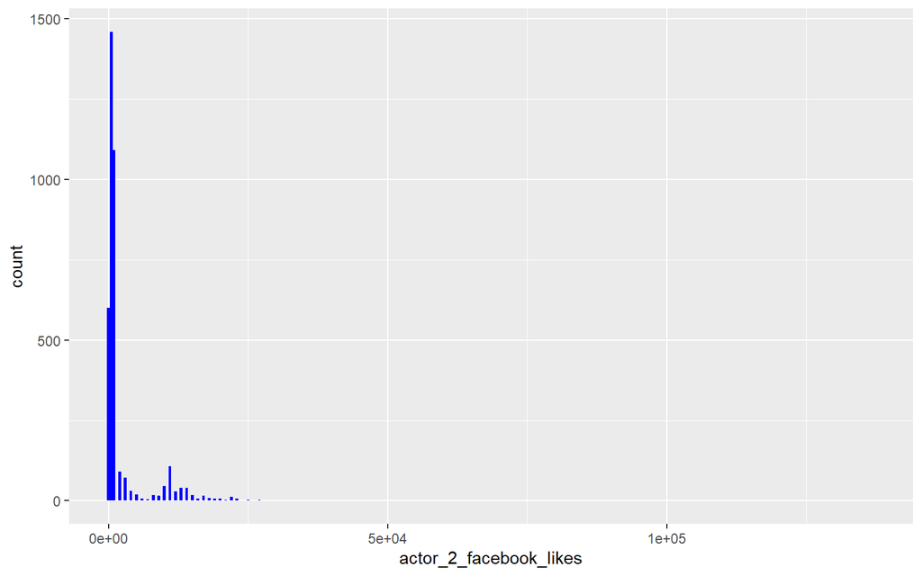

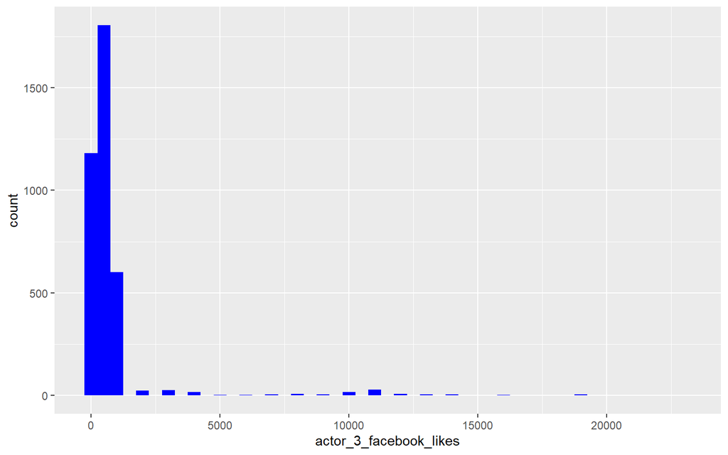

**Scatter Plots**